# p8131_hw7_mp3745

Matthew Parker

2020-04-14

#### 1.

Read in the data

```r
pitch_df = read_csv("./data/HW7-politeness_data.csv")
```

Provide boxplots to show the relation between gender/attitude and pitch (ignoring dierent scenarios)

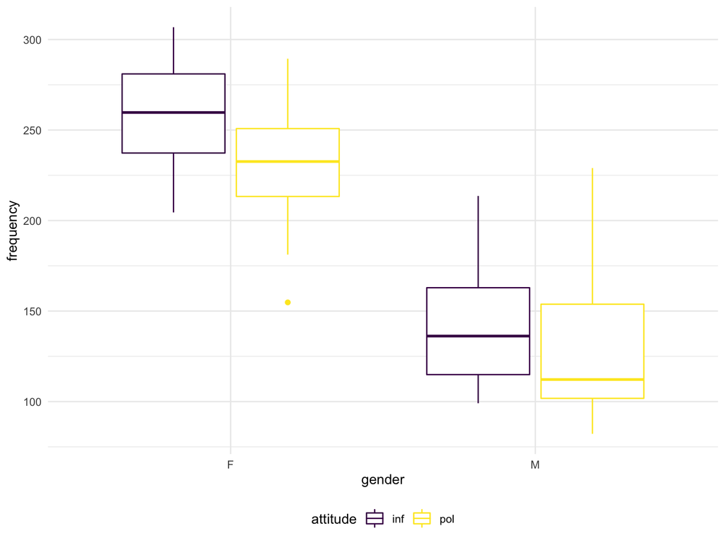

```r
pitch_df %>%
  group_by(gender, attitude) %>%
  ggplot(aes(x = gender, y = frequency, color = attitude)) +
  geom_boxplot()
```

Fromt the above boxplots, it appears that females tend to have a higher frequency than males. In addition, those with informal attitude may have a slightly higher pitch than those with polite attitude.

#### 2.

Fit a mixed effects model with random intercepts for different subjects (gender and attitude being fixed effects)

```r
# model fit
lmm_1 = lme(frequency ~ gender + attitude, random = ~1 | subject,  data = pitch_df, method = 'REML')

# summary
summary(lmm_1)
```

```
## Linear mixed-effects model fit by REML
##  Data: pitch_df
##        AIC      BIC    logLik
##   806.0805 818.0527 -398.0402
##
## Random effects:
##  Formula: ~1 | subject
##         (Intercept) Residual
## StdDev:    24.45803 29.11537
##
## Fixed effects: frequency ~ gender + attitude
##                  Value Std.Error DF   t-value p-value
## (Intercept)  256.98690 15.154986 77 16.957251  0.0000
## genderM     -108.79762 20.956235  4 -5.191659  0.0066
## attitudepol  -20.00238  6.353495 77 -3.148248  0.0023
##  Correlation:
##             (Intr) gendrM
## genderM     -0.691
## attitudepol -0.210  0.000
##
## Standardized Within-Group Residuals:
##        Min         Q1        Med         Q3        Max
## -2.3564422 -0.5658319 -0.2011979  0.4617895  3.2997610
##
## Number of Observations: 84
## Number of Groups: 6
```

Covariance matrix for Yi

```r
# sigma b squared
sigma_b_sq = as.numeric(VarCorr(lmm_1)[1])

# sigma squared
sigma_sq = as.numeric(VarCorr(lmm_1)[2])

# Covariance matrix for Yi
cov_yi = matrix(
  c(sigma_b_sq + sigma_sq, sigma_b_sq, "...", sigma_b_sq,
    sigma_b_sq, sigma_b_sq + sigma_sq, "...", sigma_b_sq,
    "...", "...", "...", "...",
    sigma_b_sq, sigma_b_sq, "...", sigma_b_sq + sigma_sq), 4, 4
)

cov_yi
```

```
##      [,1]        [,2]        [,3]  [,4]
## [1,] "1445.9002" "598.1953"  "..." "598.1953"
## [2,] "598.1953"  "1445.9002" "..." "598.1953"
## [3,] "..."       "..."       "..." "..."
## [4,] "598.1953"  "598.1953"  "..." "1445.9002"
```

Covariance matrix for REML estimates of fixed effects

```r
vcov(lmm_1)
```

```
##             (Intercept)       genderM   attitudepol
## (Intercept)   229.67362 -2.195819e+02 -2.018345e+01
## genderM      -219.58189  4.391638e+02  6.451438e-15
## attitudepol   -20.18345  6.451438e-15  4.036690e+01
```

BLUPs for subject specific intercepts

```r
random.effects(lmm_1)
```

```
##    (Intercept)
## F1  -13.575831
## F2   10.170522
## F3    3.405309
## M3   27.960288
## M4    4.739325
## M7  -32.699613
```

Residuals

```r
pitch_df$frequency - fitted(lmm_1)
```

[output not shown]

#### 3.

Fit a mixed effects model with random intercepts for different subjects (gender, attitude, and gender*attitude being fixed effects)

```r
# model fit
lmm_2 = lme(frequency ~ gender*attitude, random = ~1 | subject,  data = pitch_df, method = 'REML')

# summary
summary(lmm_2)
```

```
## Linear mixed-effects model fit by REML
##  Data: pitch_df
##        AIC     BIC    logLik
##   799.8018 814.094 -393.9009
##
## Random effects:
##  Formula: ~1 | subject
##         (Intercept) Residual
## StdDev:    24.46382 29.04716
##
## Fixed effects: frequency ~ gender * attitude
##                          Value Std.Error DF   t-value p-value
## (Intercept)          260.68571 15.481307 76 16.838740  0.0000
## genderM             -116.19524 21.893875  4 -5.307203  0.0061
## attitudepol          -27.40000  8.964149 76 -3.056620  0.0031
## genderM:attitudepol   14.79524 12.677221 76  1.167073  0.2468
##  Correlation:
##                     (Intr) gendrM atttdp
## genderM             -0.707
## attitudepol         -0.290  0.205
## genderM:attitudepol  0.205 -0.290 -0.707
##
## Standardized Within-Group Residuals:
##        Min         Q1        Med         Q3        Max
## -2.2344163 -0.5454437 -0.1646159  0.4697182  3.1800944
##
## Number of Observations: 84
## Number of Groups: 6
```

Compare the two models by likelihood ratio test

```r
# model 1 with ML estimate
lmm_1_ml = lme(frequency ~ gender + attitude, random = ~1 | subject,  data = pitch_df, method = 'ML')

# model 2 with ML estimate
lmm_2_ml = lme(frequency ~ gender*attitude, random = ~1 | subject,  data = pitch_df, method = 'ML')

# Compare
anova(lmm_1_ml, lmm_2_ml)
```

```
##          Model df      AIC      BIC    logLik   Test  L.Ratio p-value
## lmm_1_ml     1  5 825.6363 837.7904 -407.8182
## lmm_2_ml     2  6 826.2508 840.8357 -407.1254 1 vs 2 1.385523  0.2392
```

Since the p-value from the likelihood ratio test is > 0.05, we fail to reject the null hypothesis that the two models fit the data equally well. Because of this, it appears the interaction between gender and attitude is not significantly associated with pitch.

#### 4.

The model is handwritten.

Fit the model with random intercepts and random slopes for attitude for different subjects (gender and attitude are also fixed effects)

```r
# Random intercept and slope for attitude
lmm_3 = lme(frequency ~ gender + attitude, random = ~ 1 + attitude | subject,  data = pitch_df, method = 'REML')

# Summary
summary(lmm_3)
```

```
## Linear mixed-effects model fit by REML
##  Data: pitch_df
##        AIC      BIC    logLik
##   810.0805 826.8416 -398.0402
##
## Random effects:
##  Formula: ~1 + attitude | subject
##  Structure: General positive-definite, Log-Cholesky parametrization
##             StdDev       Corr
## (Intercept) 24.458032213 (Intr)
## attitudepol  0.003285569 0
## Residual    29.115372269
##
## Fixed effects: frequency ~ gender + attitude
##                  Value Std.Error DF   t-value p-value
## (Intercept)  256.98691 15.154987 77 16.957250  0.0000
## genderM     -108.79762 20.956235  4 -5.191659  0.0066
## attitudepol  -20.00238  6.353495 77 -3.148248  0.0023
##  Correlation:
##             (Intr) gendrM
## genderM     -0.691
## attitudepol -0.210  0.000
##
## Standardized Within-Group Residuals:
##        Min         Q1        Med         Q3        Max
## -2.3564422 -0.5658319 -0.2011979  0.4617896  3.2997610
##
## Number of Observations: 84
## Number of Groups: 6
```

Var(Yi) is handwritten

```r
# fixed effects
fixed.effects(lmm_3)
```

```
## (Intercept)     genderM attitudepol
##   256.98691  -108.79762   -20.00238
```

```r
# random effect
ranef(lmm_3)
```

```
##    (Intercept)   attitudepol
## F1  -13.575831 -8.408891e-07
## F2   10.170522  1.499413e-07
## F3    3.405308 -2.981919e-07
## M3   27.960288  1.009764e-06
## M4    4.739325  7.794162e-07
## M7  -32.699612 -8.000404e-07
```